# Project_Model_Tuning_ReneWind_FullCode

```python
# Reporting the performance metrics of the model on training and validation sets
bgc_under_perform = model_eval(bgc_under, X_train_under, X_valid, y_train_under, y_valid)
bgc_under_perform
```

|  | Accuracy | Recall | Precision | F1 | Specificity |
| --- | --- | --- | --- | --- | --- |
| Train | 0.990 | 0.983 | 0.998 | 0.990 | 0.998 |
| Validation | 0.928 | 0.871 | 0.428 | 0.574 | 0.932 |

```python
# Finding the region of uncertainty for the recall score of the model

# Setting the strategy for splitting the data into 10 random folds
kfold = StratifiedKFold(n_splits = 10, shuffle = True, random_state = 1)

# Calculating the cross-validated scores
cv_results = cross_val_score(bgc_under, X_train_under, y_train_under, scoring = 'recall', cv = kfold, n_jobs = -1)
cv_mean = cv_results.mean()
cv_std  = cv_results.std()

# Reporting the model's average recall score and confidence interval
print('The average recall score of the model is {} and,'.format(round(cv_mean, 3)),
      'with 95% certainty, its recall score resides between {} and {}.'.format(
          round(cv_mean-2*cv_std, 3), round(cv_mean+2*cv_std, 3)))
```

```
The average recall score of the model is 0.888 and, with 95% certainty, its recall score resides between 0.862 and 0.915.
```

**`Random Forest`**

```python
# Building the undersampled model
rfc_under = RandomForestClassifier(random_state = 1)
rfc_under = rfc_under.fit(X_train_under, y_train_under)
```

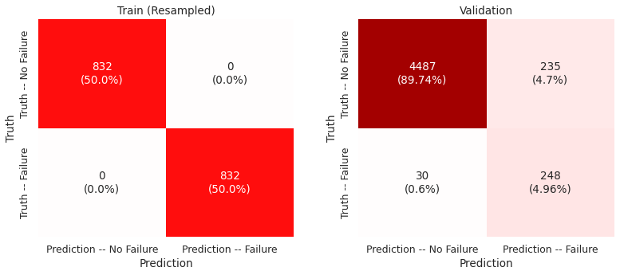

```python
# Plotting the confusion matrices of the model on training and validation sets

# Reconstructing the training set
y_recon = rfc_under.predict(X_train_under)
# Forecasting the validation set
y_pred = rfc_under.predict(X_valid)

# Plotting the heatmaps of confusion matrices
plt.figure(figsize = (11, 5));
plt.subplot(121);
plot_cm(y_train_under, y_recon);
plt.title('Train (Resampled)');
plt.subplot(122);
plot_cm(y_valid, y_pred);
plt.title('Validation');
plt.tight_layout(w_pad = 3);
```

```python
# Reporting the performance metrics of the model on training and validation sets
rfc_under_perform = model_eval(rfc_under, X_train_under, X_valid, y_train_under, y_valid)
rfc_under_perform
```

|  | Accuracy | Recall | Precision | F1 | Specificity |
| --- | --- | --- | --- | --- | --- |
| Train | 1.000 | 1.000 | 1.000 | 1.000 | 1.000 |
| Validation | 0.947 | 0.892 | 0.513 | 0.652 | 0.950 |

```python
# Finding the region of uncertainty for the recall score of the model

# Setting the strategy for splitting the data into 10 random folds
kfold = StratifiedKFold(n_splits = 10, shuffle = True, random_state = 1)

# Calculating the cross-validated scores
cv_results = cross_val_score(rfc_under, X_train_under, y_train_under, scoring = 'recall', cv = kfold, n_jobs = -1)
cv_mean = cv_results.mean()
cv_std  = cv_results.std()

# Reporting the model's average recall score and confidence interval
print('The average recall score of the model is {} and,'.format(round(cv_mean, 3)),
      'with 95% certainty, its recall score resides between {} and {}.'.format(
          round(cv_mean-2*cv_std, 3), round(cv_mean+2*cv_std, 3)))
```

```
The average recall score of the model is 0.898 and, with 95% certainty, its recall score resides between 0.844 and 0.952.
```

**`Adaptive Boosting Classifier`**

```python
# Building the undersampled model
abc_under = AdaBoostClassifier(random_state = 1)
abc_under = abc_under.fit(X_train_under, y_train_under)
```

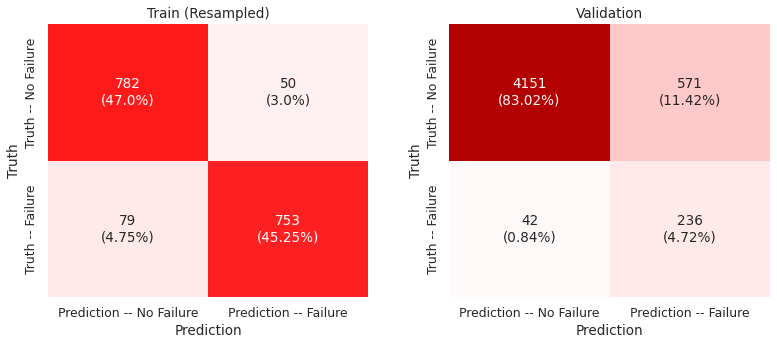

```python
# Plotting the confusion matrices of the model on training and validation sets

# Reconstructing the training set
y_recon = abc_under.predict(X_train_under)
# Forecasting the validation set
y_pred = abc_under.predict(X_valid)

# Plotting the heatmaps of confusion matrices
plt.figure(figsize = (11, 5));
plt.subplot(121);
plot_cm(y_train_under, y_recon);
plt.title('Train (Resampled)');
plt.subplot(122);
plot_cm(y_valid, y_pred);
plt.title('Validation');
plt.tight_layout(w_pad = 3);
```

```python
# Reporting the performance metrics of the model on training and validation sets
abc_under_perform = model_eval(abc_under, X_train_under, X_valid, y_train_under, y_valid)
abc_under_perform
```

|  | Accuracy | Recall | Precision | F1 | Specificity |
| --- | --- | --- | --- | --- | --- |
| Train | 0.922 | 0.905 | 0.938 | 0.921 | 0.940 |
| Validation | 0.877 | 0.849 | 0.292 | 0.435 | 0.879 |

```python
# Finding the region of uncertainty for the recall score of the model

# Setting the strategy for splitting the data into 10 random folds
kfold = StratifiedKFold(n_splits = 10, shuffle = True, random_state = 1)

# Calculating the cross-validated scores
cv_results = cross_val_score(abc_under, X_train_under, y_train_under, scoring = 'recall', cv = kfold, n_jobs = -1)
cv_mean = cv_results.mean()
cv_std  = cv_results.std()

# Reporting the model's average recall score and confidence interval
print('The average recall score of the model is {} and,'.format(round(cv_mean, 3)),
      'with 95% certainty, its recall score resides between {} and {}.'.format(
          round(cv_mean-2*cv_std, 3), round(cv_mean+2*cv_std, 3)))
```

```
The average recall score of the model is 0.875 and, with 95% certainty, its recall score resides between 0.818 and 0.932.
```

**`Gradient Boosting Classifier`**

```python
# Building the undersampled model
gbc_under = GradientBoostingClassifier(random_state = 1)
gbc_under = gbc_under.fit(X_train_under, y_train_under)
```

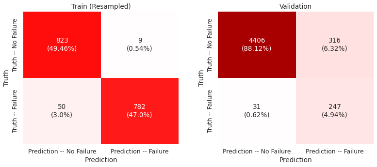

```python
# Plotting the confusion matrices of the model on training and validation sets

# Reconstructing the training set
y_recon = gbc_under.predict(X_train_under)
# Forecasting the validation set
y_pred = gbc_under.predict(X_valid)

# Plotting the heatmaps of confusion matrices
plt.figure(figsize = (11, 5));
plt.subplot(121);
plot_cm(y_train_under, y_recon);
plt.title('Train (Resampled)');
plt.subplot(122);
plot_cm(y_valid, y_pred);
plt.title('Validation');
plt.tight_layout(w_pad = 3);
```

```python
# Reporting the performance metrics of the model on training and validation sets
gbc_under_perform = model_eval(gbc_under, X_train_under, X_valid, y_train_under, y_valid)
gbc_under_perform
```

|  | Accuracy | Recall | Precision | F1 | Specificity |
| --- | --- | --- | --- | --- | --- |
| Train | 0.965 | 0.940 | 0.989 | 0.964 | 0.989 |
| Validation | 0.931 | 0.888 | 0.439 | 0.587 | 0.933 |

```python
# Finding the region of uncertainty for the recall score of the model

# Setting the strategy for splitting the data into 10 random folds
kfold = StratifiedKFold(n_splits = 10, shuffle = True, random_state = 1)

# Calculating the cross-validated scores
cv_results = cross_val_score(gbc_under, X_train_under, y_train_under, scoring = 'recall', cv = kfold, n_jobs = -1)
cv_mean = cv_results.mean()
cv_std  = cv_results.std()

# Reporting the model's average recall score and confidence interval
print('The average recall score of the model is {} and,'.format(round(cv_mean, 3)),
      'with 95% certainty, its recall score resides between {} and {}.'.format(
          round(cv_mean-2*cv_std, 3), round(cv_mean+2*cv_std, 3)))
```

```
The average recall score of the model is 0.895 and, with 95% certainty, its recall score resides between 0.865 and 0.926.
```

**`XGBoost Classifier`**

```python
# Building the undersampled model
xgbc_under = XGBClassifier(eval_metric = 'logloss', random_state = 1)
xgbc_under = xgbc_under.fit(X_train_under, y_train_under)
```

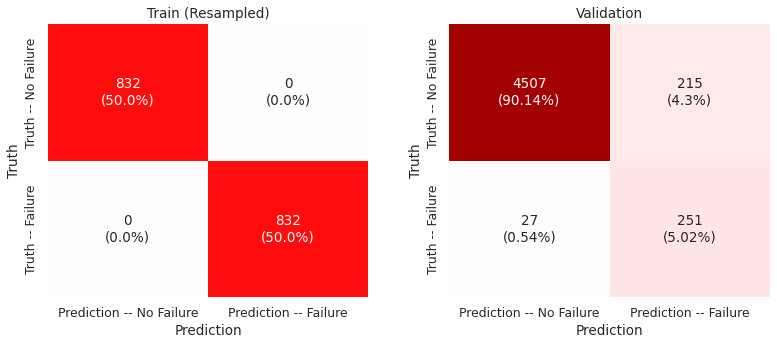

```python
# Plotting the confusion matrices of the model on training and validation sets

# Reconstructing the training set
y_recon = xgbc_under.predict(X_train_under)
# Forecasting the validation set
y_pred = xgbc_under.predict(X_valid)

# Plotting the heatmaps of confusion matrices
plt.figure(figsize = (11, 5));
plt.subplot(121);
plot_cm(y_train_under, y_recon);
plt.title('Train (Resampled)');
plt.subplot(122);
plot_cm(y_valid, y_pred);
plt.title('Validation');
plt.tight_layout(w_pad = 3);
```

```python
# Reporting the performance metrics of the model on training and validation sets
xgbc_under_perform = model_eval(xgbc_under, X_train_under, X_valid, y_train_under, y_valid)
xgbc_under_perform
```

|  | Accuracy | Recall | Precision | F1 | Specificity |
| --- | --- | --- | --- | --- | --- |
| Train | 1.000 | 1.000 | 1.000 | 1.000 | 1.000 |
| Validation | 0.952 | 0.903 | 0.539 | 0.675 | 0.954 |

```python
# Finding the region of uncertainty for the recall score of the model

# Setting the strategy for splitting the data into 10 random folds
kfold = StratifiedKFold(n_splits = 10, shuffle = True, random_state = 1)

# Calculating the cross-validated scores
cv_results = cross_val_score(xgbc_under, X_train_under, y_train_under, scoring = 'recall', cv = kfold, n_jobs = -1)
cv_mean = cv_results.mean()
cv_std  = cv_results.std()

# Reporting the model's average recall score and confidence interval
print('The average recall score of the model is {} and,'.format(round(cv_mean, 3)),
      'with 95% certainty, its recall score resides between {} and {}.'.format(
          round(cv_mean-2*cv_std, 3), round(cv_mean+2*cv_std, 3)))
```

```
The average recall score of the model is 0.903 and, with 95% certainty, its recall score resides between 0.859 and 0.946.
```

**`Comparison`**

```python
# Comparison of all undersampled models on training set
undersampled_compare_train = pd.concat([lrc_under_perform, dtr_under_perform, bgc_under_perform,
                                        rfc_under_perform, abc_under_perform, gbc_under_perform,
                                        xgbc_under_perform])[::2]
undersampled_compare_train.index = ['Logistic Regression (Undersampled)', 'Decision Tree (Undersampled)',
                                    'Bagging (Undersampled)', 'Random Forest (Undersampled)',
                                    'AdaBoost (Undersampled)', 'Gradient Boosting (Undersampled)',
                                    'XGBoost (Undersampled)']
undersampled_compare_train.sort_values(by = 'Recall', ascending = False)
```

|  | Accuracy | Recall | Precision | F1 | Specificity |
| --- | --- | --- | --- | --- | --- |
| Decision Tree (Undersampled) | 1.000 | 1.000 | 1.000 | 1.000 | 1.000 |
| Random Forest (Undersampled) | 1.000 | 1.000 | 1.000 | 1.000 | 1.000 |
| XGBoost (Undersampled) | 1.000 | 1.000 | 1.000 | 1.000 | 1.000 |
| Bagging (Undersampled) | 0.990 | 0.983 | 0.998 | 0.990 | 0.998 |
| Gradient Boosting (Undersampled) | 0.965 | 0.940 | 0.989 | 0.964 | 0.989 |
| AdaBoost (Undersampled) | 0.922 | 0.905 | 0.938 | 0.921 | 0.940 |
| Logistic Regression (Undersampled) | 0.873 | 0.875 | 0.872 | 0.873 | 0.871 |

```python
# Comparison of all oversampled models on training set
undersampled_compare_valid = pd.concat([lrc_under_perform, dtr_under_perform, bgc_under_perform,
                                        rfc_under_perform, abc_under_perform, gbc_under_perform,
                                        xgbc_under_perform])[1::2]
undersampled_compare_valid.index = ['Logistic Regression (Undersampled)', 'Decision Tree (Undersampled)',
                                    'Bagging (Undersampled)', 'Random Forest (Undersampled)',
                                    'AdaBoost (Undersampled)','Gradient Boosting (Undersampled)',
                                    'XGBoost (Undersampled)']
undersampled_compare_valid.sort_values(by = 'Recall', ascending = False)
```

|  | Accuracy | Recall | Precision | F1 | Specificity |
| --- | --- | --- | --- | --- | --- |
| XGBoost (Undersampled) | 0.952 | 0.903 | 0.539 | 0.675 | 0.954 |
| Random Forest (Undersampled) | 0.947 | 0.892 | 0.513 | 0.652 | 0.950 |
| Gradient Boosting (Undersampled) | 0.931 | 0.888 | 0.439 | 0.587 | 0.933 |
| Bagging (Undersampled) | 0.928 | 0.871 | 0.428 | 0.574 | 0.932 |
| Logistic Regression (Undersampled) | 0.858 | 0.853 | 0.261 | 0.400 | 0.858 |
| AdaBoost (Undersampled) | 0.877 | 0.849 | 0.292 | 0.435 | 0.879 |
| Decision Tree (Undersampled) | 0.831 | 0.842 | 0.226 | 0.356 | 0.830 |

#### Observations:

- The recall scores on validation sets have slightly improved compared to the oversamped models, but this has come at the price of significanly reducing the precision scores.
- The major decline in precision emerges, since, in the case of undersampled models, the training set is too small with respect to its original size, as the vast majority of 'No Failure' class have been thrown out, therefore the model can't learn this class properly and, as a result, can't distinguish between the two classes accurately, thus producing many FPs on an unseen dataset (like validation set).
- All models still suffer from overfitting. Even if their recall scores don't drop much from the training to validation set, their precision scores certainly do.

## Model Comparison

**`Training Set`**

```python
# Combining the training performance tables of all baseline, oversampled and undersampeled models
train_perform = pd.concat([baseline_compare_train, oversampled_compare_train, undersampled_compare_train])
train_perform.sort_values(by = 'Recall', ascending = False)
```

|  | Accuracy | Recall | Precision | F1 | Specificity |
| --- | --- | --- | --- | --- | --- |
| Random Forest (Oversampled) | 1.000 | 1.000 | 1.000 | 1.000 | 1.000 |
| Decision Tree (Oversampled) | 1.000 | 1.000 | 1.000 | 1.000 | 1.000 |
| Random Forest (Undersampled) | 1.000 | 1.000 | 1.000 | 1.000 | 1.000 |
| Decision Tree (Undersampled) | 1.000 | 1.000 | 1.000 | 1.000 | 1.000 |
| XGBoost (Oversampled) | 1.000 | 1.000 | 1.000 | 1.000 | 1.000 |
| Decision Tree (Baseline) | 1.000 | 1.000 | 1.000 | 1.000 | 1.000 |
| XGBoost (Undersampled) | 1.000 | 1.000 | 1.000 | 1.000 | 1.000 |
| XGBoost (Baseline) | 1.000 | 1.000 | 1.000 | 1.000 | 1.000 |
| Random Forest (Baseline) | 1.000 | 1.000 | 1.000 | 1.000 | 1.000 |
| Bagging (Oversampled) | 0.999 | 0.998 | 1.000 | 0.999 | 1.000 |
| Bagging (Undersampled) | 0.990 | 0.983 | 0.998 | 0.990 | 0.998 |
| Bagging (Baseline) | 0.997 | 0.957 | 0.997 | 0.977 | 1.000 |
| Gradient Boosting (Undersampled) | 0.965 | 0.940 | 0.989 | 0.964 | 0.989 |
| Gradient Boosting (Oversampled) | 0.953 | 0.930 | 0.975 | 0.952 | 0.976 |
| AdaBoost (Undersampled) | 0.922 | 0.905 | 0.938 | 0.921 | 0.940 |
| AdaBoost (Oversampled) | 0.913 | 0.900 | 0.923 | 0.911 | 0.925 |
| Logistic Regression (Oversampled) | 0.880 | 0.884 | 0.878 | 0.881 | 0.877 |
| Logistic Regression (Undersampled) | 0.873 | 0.875 | 0.872 | 0.873 | 0.871 |
| Gradient Boosting (Baseline) | 0.990 | 0.823 | 0.986 | 0.897 | 0.999 |
| AdaBoost (Baseline) | 0.978 | 0.659 | 0.923 | 0.769 | 0.997 |
| Logistic Regression (Baseline) | 0.967 | 0.496 | 0.843 | 0.625 | 0.995 |

#### Observations:

- The Decision Tree and Random Forest Classifiers return perfect score for all performance metrics on the training set, regardless of using the original or resampled data. This is because, we haven't set any constraint on the complexity of these models yet, so their trees can grow unboundedly to label every single data point correctly.
- The XGBoost Classifier also yields 100% for all evaluation metrics on the training set. Note that the base estimator of this method is more complex than those of the the other boosing methods. For instance, by default, the max_depth of an XGBoost Classifier is 6, whereas those of the AdaBoost and Gradient Boosting Classifiers are 1 and 3, respectively.
- The Logistic Regression model, which is less susceptible to overfitting, and the boosting methods, that use less complex base estimators, unsurprisingly fall at the bottom of the list.

**`Validation Set`**

```python
# Combining the training performance tables of all baseline, oversampled and undersampeled models
valid_perform = pd.concat([baseline_compare_valid, oversampled_compare_valid, undersampled_compare_valid])
valid_perform.sort_values(by = 'Recall', ascending = False)
```

|  | Accuracy | Recall | Precision | F1 | Specificity |
| --- | --- | --- | --- | --- | --- |
| XGBoost (Undersampled) | 0.952 | 0.903 | 0.539 | 0.675 | 0.954 |
| Random Forest (Undersampled) | 0.947 | 0.892 | 0.513 | 0.652 | 0.950 |
| Gradient Boosting (Undersampled) | 0.931 | 0.888 | 0.439 | 0.587 | 0.933 |
| Gradient Boosting (Oversampled) | 0.963 | 0.878 | 0.619 | 0.726 | 0.968 |
| Bagging (Undersampled) | 0.928 | 0.871 | 0.428 | 0.574 | 0.932 |
| XGBoost (Oversampled) | 0.987 | 0.863 | 0.896 | 0.879 | 0.994 |
| AdaBoost (Oversampled) | 0.912 | 0.860 | 0.375 | 0.522 | 0.916 |
| Logistic Regression (Undersampled) | 0.858 | 0.853 | 0.261 | 0.400 | 0.858 |
| AdaBoost (Undersampled) | 0.877 | 0.849 | 0.292 | 0.435 | 0.879 |
| Logistic Regression (Oversampled) | 0.868 | 0.849 | 0.277 | 0.418 | 0.870 |
| Random Forest (Oversampled) | 0.988 | 0.845 | 0.940 | 0.890 | 0.997 |
| Decision Tree (Undersampled) | 0.831 | 0.842 | 0.226 | 0.356 | 0.830 |
| Bagging (Oversampled) | 0.980 | 0.835 | 0.806 | 0.820 | 0.988 |
| XGBoost (Baseline) | 0.989 | 0.813 | 0.983 | 0.890 | 0.999 |
| Decision Tree (Oversampled) | 0.949 | 0.770 | 0.530 | 0.628 | 0.960 |
| Bagging (Baseline) | 0.983 | 0.730 | 0.949 | 0.825 | 0.998 |
| Random Forest (Baseline) | 0.984 | 0.727 | 0.985 | 0.836 | 0.999 |
| Gradient Boosting (Baseline) | 0.981 | 0.723 | 0.910 | 0.806 | 0.996 |
| Decision Tree (Baseline) | 0.966 | 0.705 | 0.688 | 0.696 | 0.981 |
| AdaBoost (Baseline) | 0.976 | 0.676 | 0.866 | 0.760 | 0.994 |
| Logistic Regression (Baseline) | 0.966 | 0.486 | 0.844 | 0.616 | 0.995 |

#### Observations:

**`Cross-Validation`**

[figure not shown]

```python
# No. of cross-validation folds
n_folds = 10
# List of all estimators
models_list = [lrc0, dtr0, bgc0, rfc0, abc0, gbc0, xgbc0]
# Making a dataframe for the cross-validated recall scores of all resampled models
cv_results_df = pd.DataFrame(np.zeros([n_folds, len(models_list)*2]),
                             columns = ['LRC (Over)', 'LRC (Under)', 'DTR (Over)', 'DTR (Under)',
                                        'BGC (Over)', 'BGC (Under)', 'RFC (Over)', 'RFC (Under)',
                                        'ABC (Over)', 'ABC (Under)', 'GBC (Over)', 'GBC (Under)',
                                        'XGBC (Over)', 'XGBC (Under)'])
# Setting the randomized data splitting strategy
kfold = StratifiedKFold(n_splits = n_folds, shuffle = True, random_state = 1)
for i, model in enumerate(models_list):
    cv_results_df.iloc[:, 2*i] = cross_val_score(model, X_train_over, y_train_over,
                                                 scoring = 'recall', cv = kfold, n_jobs = -1)
    cv_results_df.iloc[:, 2*i+1] = cross_val_score(model, X_train_under, y_train_under,
                                                   scoring = 'recall', cv = kfold, n_jobs = -1)
# Plotting the boxplot distribution of cross-validated recall scores of all resampled models
plt.figure(figsize = (18, 5))
sns.boxplot(data = cv_results_df.iloc[0:4, :], showmeans = True, dodge = True, meanprops =
            {'marker': 'x', 'markerfacecolor': 'red', 'markeredgecolor': 'red', 'markersize': '7'});
plt.xlabel('Model');
plt.ylabel('Recall Score');
plt.xticks(rotation = 45);
plt.yticks(ticks = np.arange(0.8, 1.01, 0.05));
plt.ylim(0.8, 1);
```

#### Observations:

- As can be noted, the undersampled models have typically wider confidence intervals, since they are trained on smaller datasets, increasing the uncertainty of their results.
- The average and median cross-validated recall scores of the oversampled models are somewhat higher than those of their undersampled counterparts.
- The recall scores of the Decision Tree, Bagging, Random Forest and XGBoost Classifiers on the oversampled data stand out from the other models. Note that these models haven't been tuned yet, i.e. their base estimators might get very complex, making them specifically tailored for the dataset on which they've been trained. The first three can grow unboundedly if no limit is set, and the default depth of the XGBoost Classifier is 6, which is much higher than that of the other boosting methods. Furthermore, they have benefitted from a synthetically large and balanced training set, with different target class frequencies compared to the validation set. Consequently, they can't replicate these high cross-validated scores on the validation set, and validation scores may not even fall in their confidence intervals.
- The results for the baseline models weren't depicted, as it was already established that these models are inferior to the resampled models.
- Note that the baseline and resampled models have the same hyperparameters (and are technically identical). This is why using them in the model list, instead of let's say replacing bgc0 by bgc_over or bgc_under, doesn't make any difference in the above analysis.

## HyperparameterTuning

- As seen above, from the recall score perspective, the best-performing models on the validation are the undersampled models. On the other hand, the oversampled models have narrower confidence intervals and higher cross-validated scores than their undersampled counterparts, and don't sacrifice precision much for the sake of maximizing recall. Therefore, we select the seven models with the highest validation recall scores for model tuning. This set of models hass a nearly balanced share of both oversampled and undersampled classifiers: three of the former and four of the latter.
- Number of cross-validation folds for all models is set at 5, which is half of what we used for finding the confidence intervals. Note that accurate calculation of mean and standard deviation of cross-validated scores typically requires a larger number of data folds.
- Number of random draws (n_iter) in the randomized search algorithm varies between 50 and 100, depending on the variety of hyperparameters a classification method provides.
- For this section, we've defined our own recall scorer, yielding the correct recall score all the time, except when the recall is one, in which case, it returns zero. This is to prevent development of models that maximize recall by labeling everything class 1 ('Failure'). Additionally, using this scorer helps mitigate the overfitting problem. Note that this function will be used only inside the model tuning search algorithm, and not for calculating the actual recall score, when a model is built/tuned.

```python
# In-house recall score
def my_recall(y_truth, y_pred):
    '''This function return the correct recall score except when recall = 1.
    In that case, it returns 0.'''
    recall = recall_score(y_truth, y_pred)
    if recall == 1:
        recall = 0
    return recall
```

**`Bagging Classifier (Undersampled)`**

```python
# Defining the base estimator
cv_model = bgc_under

# Defining the cross-validation training sets
X_cv = X_train_under
y_cv = y_train_under

# Defining the performance measure
acc_criterion = make_scorer(my_recall)

# Defining the range of hyperparameters
hyperparams = {'n_estimators': np.arange(50, 301, 50), 'max_samples': np.arange(0.5, 1.01, 0.1),
               'max_features': list(np.arange(0.2, 1.01, 0.2)) + ['sqrt', 'log2'],
               'base_estimator': [DecisionTreeClassifier(max_depth = 4, random_state = 1),
                                  DecisionTreeClassifier(max_depth = 5, random_state = 1),
                                  DecisionTreeClassifier(max_depth = 6, random_state = 1),
                                  DecisionTreeClassifier(max_depth = 7, random_state = 1)]}

# Looping over the entire discretized hyperparameter space
all_models = RandomizedSearchCV(estimator = cv_model, param_distributions = hyperparams,
                                n_iter = 50, scoring = acc_criterion, cv = 5,
                                n_jobs = -1, random_state = 1, verbose = 1)
all_models = all_models.fit(X_cv, y_cv)

# Choosing the best model
bgc_tuned_us = all_models.best_estimator_
bgc_tuned_us = bgc_tuned_us.fit(X_cv, y_cv)
print('Selected hyperparameters:\n', all_models.best_params_, sep = '')
```

```
Fitting 5 folds for each of 50 candidates, totalling 250 fits
Selected hyperparameters:
{'n_estimators': 200, 'max_samples': 0.7, 'max_features': 0.4, 'base_estimator': DecisionTreeClassifier(max_depth=6, random_state=1)}
```

```python
# Reporting the performance of the tuned model on training and validation sets
bgc_tuned_us_perform = model_eval(bgc_tuned_us, X_cv, X_valid, y_cv, y_valid)
bgc_tuned_us_perform
```

|  | Accuracy | Recall | Precision | F1 | Specificity |
| --- | --- | --- | --- | --- | --- |
| Train | 0.950 | 0.916 | 0.982 | 0.948 | 0.983 |
| Validation | 0.938 | 0.878 | 0.469 | 0.612 | 0.942 |

#### Observations:

- Model tuning has slightly increased the recall score, while also increasing the precision score by around 0.04.
- The issue of overfitting has been addressed to some degree, at least when it comes to recall.

**`Random Forest (Undersampled)`**

```python
# Defining the base estimator
cv_model = rfc_under

# Defining the cross-validation training sets
X_cv = X_train_under
y_cv = y_train_under

# Defining the performance measure
acc_criterion = make_scorer(my_recall)

# Defining the range of hyperparameters
hyperparams = {'n_estimators': np.arange(50, 301, 50), 'max_features': np.arange(0.2, 1.01, 0.2),
               'max_samples': [0.5, 0.6, 0.8, 1], 'min_samples_split': [3, 6, 12, 20],
               'max_depth': np.arange(4, 8), 'min_impurity_decrease': [1e-4, 1e-3, 0.01]}

# Looping over the entire discretized hyperparameter space
all_models = RandomizedSearchCV(estimator = cv_model, param_distributions = hyperparams,
                                n_iter = 100, scoring = acc_criterion, cv = 5,
                                n_jobs = -1, random_state = 1)
all_models = all_models.fit(X_cv, y_cv)

# Choosing the best model
rfc_tuned_us = all_models.best_estimator_
rfc_tuned_us = rfc_tuned_us.fit(X_cv, y_cv)
print('Selected hyperparameters:\n', all_models.best_params_, sep = '')
```

```
Selected hyperparameters:
{'n_estimators': 250, 'min_samples_split': 6, 'min_impurity_decrease': 0.0001, 'max_samples': 0.8, 'max_features': 0.6000000000000001, 'max_depth': 7}
```

```python
# Reporting the performance of the tuned model on training and validation sets
rfc_tuned_us_perform = model_eval(rfc_tuned_us, X_cv, X_valid, y_cv, y_valid)
rfc_tuned_us_perform
```

|  | Accuracy | Recall | Precision | F1 | Specificity |
| --- | --- | --- | --- | --- | --- |
| Train | 0.952 | 0.917 | 0.986 | 0.950 | 0.987 |
| Validation | 0.944 | 0.892 | 0.497 | 0.638 | 0.947 |

#### Observations:

After model tuning, the discrepancy between the training and validation scores has been reduced to a large degree, but the precision and recall scores on the validation set have either remained the same, or have dropped slightly.

**`AdaBoost Classifier (Oversampled)`**

```python
# Defining the base estimator
cv_model = abc_over

# Defining the cross-validation training sets
X_cv = X_train_over
y_cv = y_train_over

# Defining the performance measure
acc_criterion = make_scorer(my_recall)

# Defining the range of hyperparameters
hyperparams = {'n_estimators': np.arange(50, 301, 50), 'learning_rate': np.arange(0.2, 2.01, 0.2),
               'base_estimator': [DecisionTreeClassifier(max_depth = 1, random_state = 1),
                                  DecisionTreeClassifier(max_depth = 2, random_state = 1),
                                  DecisionTreeClassifier(max_depth = 3, random_state = 1)]}

# Looping over the entire discretized hyperparameter space
all_models = RandomizedSearchCV(estimator = cv_model, param_distributions = hyperparams,
                                n_iter = 50, scoring = acc_criterion, cv = 5,
                                n_jobs = -1, random_state = 1)
all_models = all_models.fit(X_cv, y_cv)

# Choosing the best model
abc_tuned_os = all_models.best_estimator_
abc_tuned_os = abc_tuned_os.fit(X_cv, y_cv)
print('Selected hyperparameters:\n', all_models.best_params_, sep = '')
```

```
Selected hyperparameters:
{'n_estimators': 300, 'learning_rate': 1.4000000000000001, 'base_estimator': DecisionTreeClassifier(max_depth=3, random_state=1)}
```

```python
# Reporting the performance of the tuned model on training and validation sets
abc_tuned_os_perform = model_eval(abc_tuned_os, X_cv, X_valid, y_cv, y_valid)
abc_tuned_os_perform
```

|  | Accuracy | Recall | Precision | F1 | Specificity |
| --- | --- | --- | --- | --- | --- |
| Train | 1.000 | 1.000 | 1.000 | 1.000 | 1.000 |
| Validation | 0.981 | 0.835 | 0.823 | 0.829 | 0.989 |

#### Observations:

- The optimization of the model hyperparameters has perfected the performance metrics of the AdaBoost Classifier on the training set, but, unfortunately, has reduced the recall score.
- On the bright size, the precision and F1 scores have remarkably increased as a result of the optimization, which is somewhat odd, because the optimization took place on the recall score.

**`Gradient Boosting Classifier (Oversampled)`**

```python
# Defining the base estimator
cv_model = gbc_over

# Defining the cross-validation training sets
X_cv = X_train_over
y_cv = y_train_over

# Defining the performance measure
acc_criterion = make_scorer(my_recall)

# Defining the range of hyperparameters
hyperparams = {'n_estimators': np.arange(50, 301, 50), 'learning_rate': np.arange(0.2, 1.01, 0.2),
               'max_features': list(np.arange(0.2, 1.01, 0.2)) + ['sqrt', 'log2'],
               'subsample': [0.5, 0.6, 0.8, 1], 'max_depth': [3, 4, 5]}

# Looping over the entire discretized hyperparameter space
all_models = RandomizedSearchCV(estimator = cv_model, param_distributions = hyperparams,
                                n_iter = 50, scoring = acc_criterion, cv = 5,
                                n_jobs = -1, random_state = 1)
all_models = all_models.fit(X_cv, y_cv)

# Choosing the best model
gbc_tuned_os = all_models.best_estimator_
gbc_tuned_os = gbc_tuned_os.fit(X_cv, y_cv)
print('Selected hyperparameters:\n', all_models.best_params_, sep = '')
```

```
Selected hyperparameters:
{'subsample': 1, 'n_estimators': 300, 'max_features': 'sqrt', 'max_depth': 5, 'learning_rate': 0.4}
```

```python
# Reporting the performance of the tuned model on training and validation sets
gbc_tuned_os_perform = model_eval(gbc_tuned_os, X_cv, X_valid, y_cv, y_valid)
gbc_tuned_os_perform
```

|  | Accuracy | Recall | Precision | F1 | Specificity |
| --- | --- | --- | --- | --- | --- |
| Train | 1.000 | 1.000 | 1.000 | 1.000 | 1.000 |
| Validation | 0.988 | 0.867 | 0.920 | 0.893 | 0.996 |

#### Observations:

However model tuning has bridged the gap between the precision, F1 and specificity scores of the training and validation sets, but the performance metric that matters the most to us, namely, the validation recall score, has unfortunately decreased.

**`Gradient Boosting Classifier (Undersampled)`**

```python
# Defining the base estimator
cv_model = gbc_under

# Defining the cross-validation training sets
X_cv = X_train_under
y_cv = y_train_under

# Defining the performance measure
acc_criterion = make_scorer(my_recall)

# Defining the range of hyperparameters
hyperparams = {'n_estimators': np.arange(50, 301, 50), 'learning_rate': np.arange(0.2, 1.01, 0.2),
               'max_features': list(np.arange(0.2, 1.01, 0.2)) + ['sqrt', 'log2'],
               'subsample': [0.5, 0.6, 0.8, 1], 'max_depth': [3, 4, 5]}

# Looping over the entire discretized hyperparameter space
all_models = RandomizedSearchCV(estimator = cv_model, param_distributions = hyperparams,
                                n_iter = 50, scoring = acc_criterion, cv = 5,
                                n_jobs = -1, random_state = 1)
all_models = all_models.fit(X_cv, y_cv)

# Choosing the best model
gbc_tuned_us = all_models.best_estimator_
gbc_tuned_us = gbc_tuned_us.fit(X_cv, y_cv)
print('Selected hyperparameters:\n', all_models.best_params_, sep = '')
```

```
Selected hyperparameters:
{'subsample': 1, 'n_estimators': 300, 'max_features': 'sqrt', 'max_depth': 5, 'learning_rate': 0.4}
```

```python
# Reporting the performance of the tuned model on training and validation sets
gbc_tuned_us_perform = model_eval(gbc_tuned_us, X_cv, X_valid, y_cv, y_valid)
gbc_tuned_us_perform
```

|  | Accuracy | Recall | Precision | F1 | Specificity |
| --- | --- | --- | --- | --- | --- |
| Train | 1.000 | 1.000 | 1.000 | 1.000 | 1.000 |
| Validation | 0.954 | 0.896 | 0.551 | 0.682 | 0.957 |

#### Observations:

The tuning of the undersampled Gradient Boosting Classifier has improved both its precision and recall.

**`XGBoost Classifier (Oversampled)`**

```python
# Defining the base estimator
cv_model = xgbc_over

# Defining the cross-validation training sets
X_cv = X_train_over
y_cv = y_train_over

# Defining the performance measure
acc_criterion = make_scorer(my_recall)

# Defining the range of hyperparameters
hyperparams = {'n_estimators': np.arange(100, 301, 100), 'scale_pos_weight': [4, 8, 12],
               'subsample': [0.5, 0.6, 0.8, 1], 'learning_rate': np.arange(0.1, 0.51, 0.1),
               'colsample_bytree': np.arange(0.4, 1.01, 0.2), 'max_depth': [4, 5, 6],
               'colsample_bylevel': np.arange(0.4, 1.01, 0.2)}

# Looping over the entire discretized hyperparameter space
all_models = RandomizedSearchCV(estimator = cv_model, param_distributions = hyperparams,
                                n_iter = 100, scoring = acc_criterion, cv = 5,
                                n_jobs = -1, random_state = 1)
all_models = all_models.fit(X_cv, y_cv)

# Choosing the best model
xgbc_tuned_os = all_models.best_estimator_
xgbc_tuned_os = xgbc_tuned_os.fit(X_cv, y_cv)
print('Selected hyperparameters:\n', all_models.best_params_, sep = '')
```

```
Selected hyperparameters:
{'subsample': 1, 'scale_pos_weight': 12, 'n_estimators': 200, 'max_depth': 5, 'learning_rate': 0.1, 'colsample_bytree': 0.6000000000000001, 'colsample_bylevel': 0.8000000000000002}
```

```python
# Reporting the performance of the tuned model on training and validation sets
xgbc_tuned_os_perform = model_eval(xgbc_tuned_os, X_cv, X_valid, y_cv, y_valid)
xgbc_tuned_os_perform
```

|  | Accuracy | Recall | Precision | F1 | Specificity |
| --- | --- | --- | --- | --- | --- |
| Train | 0.985 | 1.000 | 0.971 | 0.985 | 0.970 |
| Validation | 0.951 | 0.896 | 0.535 | 0.670 | 0.954 |

#### Observations:

Model tuning has somewhat improved the validation recall score, and has made it closer to that on the training set, but has reduced precision. Nonetheless, precision is still fairly good for a problem in which recall is much more important.

**`XGBoost Classifier (Undersampled)`**

```python
# Defining the base estimator
cv_model = xgbc_under

# Defining the cross-validation training sets
X_cv = X_train_under
y_cv = y_train_under

# Defining the performance measure
acc_criterion = make_scorer(my_recall)

# Defining the range of hyperparameters
hyperparams = {'n_estimators': np.arange(50, 301, 100), 'subsample': [0.5, 0.6, 0.8, 1],
               'learning_rate': np.arange(0.1, 0.51, 0.1),
               'scale_pos_weight': np.arange(1, 2.01, 0.2),
               'colsample_bytree': np.arange(0.2, 1.01, 0.2),
               'colsample_bylevel': np.arange(0.2, 1.01, 0.2)}

# Looping over the entire discretized hyperparameter space
all_models = RandomizedSearchCV(estimator = cv_model, param_distributions = hyperparams,
                                n_iter = 100, scoring = acc_criterion, cv = 5,
                                n_jobs = -1, random_state = 1)
all_models = all_models.fit(X_cv, y_cv)

# Choosing the best model
xgbc_tuned_us = all_models.best_estimator_
xgbc_tuned_us = xgbc_tuned_us.fit(X_cv, y_cv)
print('Selected hyperparameters:\n', all_models.best_params_, sep = '')
```

```
Selected hyperparameters:
{'subsample': 0.8, 'scale_pos_weight': 1.7999999999999998, 'n_estimators': 250, 'learning_rate': 0.1, 'colsample_bytree': 0.4, 'colsample_bylevel': 0.4}
```

```python
# Reporting the performance of the tuned model on training and validation sets
xgbc_tuned_us_perform = model_eval(xgbc_tuned_us, X_cv, X_valid, y_cv, y_valid)
xgbc_tuned_us_perform
```

|  | Accuracy | Recall | Precision | F1 | Specificity |
| --- | --- | --- | --- | --- | --- |
| Train | 1.000 | 1.000 | 1.000 | 1.000 | 1.000 |
| Validation | 0.947 | 0.899 | 0.515 | 0.655 | 0.950 |

## Selecting the Final Model

**`Training Set`**

```python
# Comparison of all tuned models on training set
tuned_compare_train = pd.concat([bgc_tuned_us_perform, rfc_tuned_us_perform, abc_tuned_os_perform,
                                 gbc_tuned_os_perform, gbc_tuned_us_perform, xgbc_tuned_os_perform,
                                 xgbc_tuned_us_perform])[::2]
tuned_compare_train.index = ['Bagging (Undersampled)', 'Random Forest (Undersampled)',
                             'AdaBoost (Oversampled)', 'Gradient Boosting (Oversampled)',
                             'Gradient Boosting (Undersampled)', 'XGBoost (Oversampled)',
                              'XGBoost (Undersampled)']
print('Training performance metrics of the tuned models:')
tuned_compare_train.sort_values(by = 'Recall', ascending = False)
```

```
Training performance metrics of the tuned models:
```

|  | Accuracy | Recall | Precision | F1 | Specificity |
| --- | --- | --- | --- | --- | --- |
| AdaBoost (Oversampled) | 1.000 | 1.000 | 1.000 | 1.000 | 1.000 |
| Gradient Boosting (Oversampled) | 1.000 | 1.000 | 1.000 | 1.000 | 1.000 |
| Gradient Boosting (Undersampled) | 1.000 | 1.000 | 1.000 | 1.000 | 1.000 |
| XGBoost (Undersampled) | 1.000 | 1.000 | 1.000 | 1.000 | 1.000 |
| XGBoost (Oversampled) | 0.985 | 1.000 | 0.971 | 0.985 | 0.970 |
| Random Forest (Undersampled) | 0.952 | 0.917 | 0.986 | 0.950 | 0.987 |
| Bagging (Undersampled) | 0.950 | 0.916 | 0.982 | 0.948 | 0.983 |

**`Validation Set`**

```python
# Comparison of all tuned models on validation set
tuned_compare_valid = pd.concat([bgc_tuned_us_perform, rfc_tuned_us_perform, abc_tuned_os_perform,
                                 gbc_tuned_os_perform, gbc_tuned_us_perform, xgbc_tuned_os_perform,
                                 xgbc_tuned_us_perform])[1::2]
tuned_compare_valid.index = ['Bagging (Undersampled)', 'Random Forest (Undersampled)',
                             'AdaBoost (Oversampled)', 'Gradient Boosting (Oversampled)',
                             'Gradient Boosting (Undersampled)', 'XGBoost (Oversampled)',
                              'XGBoost (Undersampled)']
print('Validation performance metrics of the tuned models:')
tuned_compare_valid.sort_values(by = 'Recall', ascending = False)
```

```
Validation performance metrics of the tuned models:
```

|  | Accuracy | Recall | Precision | F1 | Specificity |
| --- | --- | --- | --- | --- | --- |
| XGBoost (Undersampled) | 0.947 | 0.899 | 0.515 | 0.655 | 0.950 |
| Gradient Boosting (Undersampled) | 0.954 | 0.896 | 0.551 | 0.682 | 0.957 |
| XGBoost (Oversampled) | 0.951 | 0.896 | 0.535 | 0.670 | 0.954 |
| Random Forest (Undersampled) | 0.944 | 0.892 | 0.497 | 0.638 | 0.947 |
| Bagging (Undersampled) | 0.938 | 0.878 | 0.469 | 0.612 | 0.942 |
| Gradient Boosting (Oversampled) | 0.988 | 0.867 | 0.920 | 0.893 | 0.996 |
| AdaBoost (Oversampled) | 0.981 | 0.835 | 0.823 | 0.829 | 0.989 |

**`Cross-Validated Scores`**

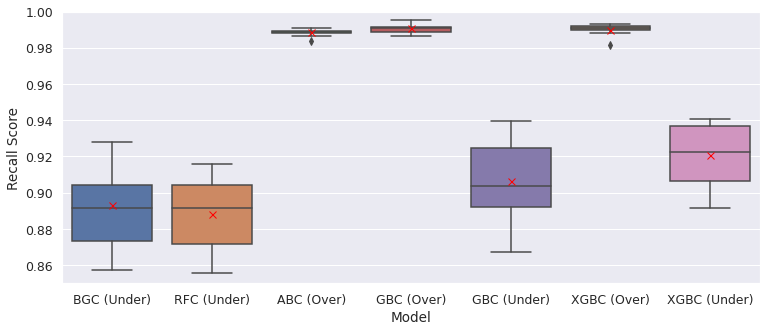

```python
# No. of cross-validation folds
n_folds = 10
# List of all estimators
models_list = [bgc_tuned_us, rfc_tuned_us, abc_tuned_os, gbc_tuned_os,
               gbc_tuned_us, xgbc_tuned_us, xgbc_tuned_os]
# Making a dataframe for the cross-validated recall scores of all resampled models
cv_results_df = pd.DataFrame(np.zeros([n_folds, 7]),
                             columns = ['BGC (Under)', 'RFC (Under)', 'ABC (Over)', 'GBC (Over)',
                                        'GBC (Under)', 'XGBC (Over)', 'XGBC (Under)'])
# Setting the randomized data splitting strategy
kfold = StratifiedKFold(n_splits = n_folds, shuffle = True, random_state = 1)
for i, model in enumerate(models_list):
    if('Over' in cv_results_df.columns.tolist()[i]):
        X_cv = X_train_over
        y_cv = y_train_over
    else:
        X_cv = X_train_under
        y_cv = y_train_under
    cv_results_df.iloc[:, i] = cross_val_score(model, X_cv, y_cv, scoring = 'recall', cv = kfold)

# Plotting the boxplot distribution of cross-validated recall scores of all resampled models
plt.figure(figsize = (12.5, 5))
sns.boxplot(data = cv_results_df, showmeans = True, dodge = True, meanprops =
            {'marker': 'x', 'markerfacecolor': 'red', 'markeredgecolor': 'red', 'markersize': '7'});
plt.xlabel('Model');
plt.ylabel('Recall Score');
plt.ylim(0.85, 1);
```

#### Observations:

- Either caused by using a randomized search, which doesn't sweep the entire hyperparameter space, or the nature of the data, model tuning didn't fully resolve the overfitting problem for all models. For instance, the tuned AdaBoost Classifier reveals perfect training scores, and a notable drop in the performance metrics on the validation set.
- Similar to what observed for untuned classifiers, the oversampled models have higher mean and median cross-validated scores and narrower confidence intervals. But since these models are still (at least somewhat) overfit, the validation score may not even fall inside the uncertainty region.
- The undersampled XGBoost Classifier has the highest validation recall score and a fairly decent precision (more than 50%) for a model aimed at maximizing recall. Furthermore, the validation score falls within its region of uncertainty, indicating that the evaluation metrics on any unseen data (like test set) shouldn't be too distant from the validation and cross-validated scores.

**`Final Model's Performance`**

```python
# Redefining the final (best) model
final_model = XGBClassifier(n_estimators = 250, subsample = 0.8, learning_rate = 0.1,
                            scale_pos_weight = 1.8, colsample_bytree = 0.4, colsample_bylevel = 0.4,
                            eval_metric = 'logloss', random_state = 1)

# Setting the training dataset of the final model
X_train_final = X_train_under
y_train_final = y_train_under
# Refitting the final model
final_model = final_model.fit(X_train_final, y_train_final)

# Reporting the performance of the final (best) model on all three sets
final_valid_perform = model_eval(final_model, X_train_final, X_valid, y_train_final, y_valid)
final_test_perform  = model_eval(final_model, X_train_final, X_test, y_train_final, y_test, valid = False)
final_model_perform = pd.concat([final_valid_perform, final_test_perform.drop(index = 'Train', axis = 0)])
final_model_perform
```

|  | Accuracy | Recall | Precision | F1 | Specificity |
| --- | --- | --- | --- | --- | --- |
| Train | 1.000 | 1.000 | 1.000 | 1.000 | 1.000 |
| Validation | 0.947 | 0.899 | 0.515 | 0.655 | 0.950 |
| Test | 0.944 | 0.872 | 0.502 | 0.637 | 0.948 |

#### Observations:

The test recall score is only slightly less than the validation recall score, but as discussed before, the uncertainty region of the (tuned) undersampled XGBoost Classifier contains the validation performance metrics and, as a result, the evaluation scores on any unseen data, including the test set, can be reasonably anticipated, and won't fall too far from those on the validation set and what are predicted by the model's confidence interval.

## Impact of Predictors

Here, we analyze the significance of various predictors, based on the results of the final model ().

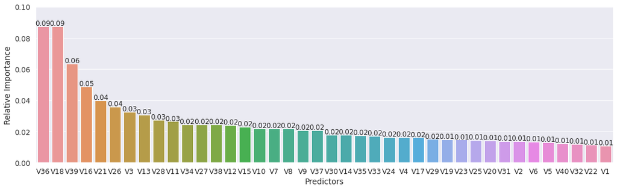

```python
# Making a dataframe of relative importance of all predictors
imp_df = pd.DataFrame({'Predictors': X.columns.tolist(), 'Relative Importance':
                        final_model.feature_importances_})
imp_df = imp_df.loc[imp_df['Relative Importance'] > 0.01]
imp_df = imp_df.sort_values(by = 'Relative Importance', ascending = False).reset_index(drop = True)

# Demonstrating the relative importance of predictors in the form of a barplot
plt.figure(figsize = (18, 5));
barplt = sns.barplot(data = imp_df, x = 'Predictors', y = 'Relative Importance');
countplot_labeling(barplt, imp_df, perc = False, decimal = 2);
plt.ylim(0, 0.1);
```

#### Observations:

- V36, V18, V39, V16 and V21 appear to be the most decisive predictors of failure, according to the undersampled XGBoost Classifier, only the last two of which (V16 of V21) showed to have a correlation above 0.2 with the target variable.
- Note that XGBoost classification is an ensemble technique, being built by hundreds of sequential weak learners, each with a different set of predictors. It thus shouldn't be surprising to see that the importance of predictors has been mixed and distributed over a wide range of features.
- As can be noted, only predictors whose relative importance exceeds 0.01 have been shown.

## Productionizing of the Final Model

Here, the best model, namely, *the tuned, undersampled XGBoost Classifier*, will be deployed in production using Pipeline().

```python
# Setting the imputation strategy
impute_strategy = imputation_scheme
# Setting the resampling strategy
resample_strategy = undersampling_scheme

# Building the pipeline for the final model
clf_pipe = Pipeline([('Imputation', impute_strategy), ('Classification Model', final_model)])
```

```python
# Redefining the training and test sets
X_train_pipe = data.drop(columns = 'Target')
y_train_pipe = data['Target']
X_test_pipe  = data_test.drop(columns = 'Target')
y_test_pipe  = data_test['Target']
```

#### Notes:

- The training and test sets have been defined again, to ensure all steps of the pipeline (missing value treatment and model building) perform properly.
- Note that, in the productionization step, the entire training data can be used for training, since no further model tuning will be conducted, thus no validation set will be needed.

```python
# Imputation of training set
X_train_pipe = pd.DataFrame(impute_strategy.fit_transform(X_train_pipe),
                            columns = X.columns.tolist())
print('No. of missing values in the training set:', X_train_pipe.isnull().sum().sum())
```

```
No. of missing values in the training set: 0
```

#### Notes:

- Missing value treatment of the training set should be conducted seperately from the pipeline, since no resampling is permissible before filling in all missing values in the data. The missing value treatment of the test set will be done in the pipeline.

```python
# Resampling the pipeline training set
X_train_pipe_resampled, y_train_pipe_resampled = resample_strategy.fit_resample(
                                                                X_train_pipe, y_train_pipe)

# Comparing the oversampled data with the original data
print('The counts of target classes in the pipeline training set before resampling:\n',
      y_train_pipe.value_counts(), end = '\n' + '**'*35 + '\n', sep = '')
print('The counts of target classes in the pipeline training set after resampling:\n',
      y_train_pipe_resampled.value_counts(), end = '\n' + '**'*35 + '\n', sep = '')
print('The fractions of target classes in the pipeline training before resampling:\n',
      y_train_pipe.value_counts(1), end = '\n' + '**'*35 + '\n', sep = '')
print('The fractions of target classes in the pipeline training set after resampling:\n',
      y_train_pipe_resampled.value_counts(1), end = '\n' + '**'*35 + '\n', sep = '')
print('The size of training set before oversampling:', X_train_pipe.shape)
print('The size of training set after oversampling:', X_train_pipe_resampled.shape)
```

```
The counts of target classes in the pipeline training set before resampling:
0    18890
1     1110
Name: Target, dtype: int64
The counts of target classes in the pipeline training set after resampling:
0    1110
1    1110
Name: Target, dtype: int64
The fractions of target classes in the pipeline training before resampling:
0   0.945
1   0.056
Name: Target, dtype: float64
The fractions of target classes in the pipeline training set after resampling:
0   0.500
1   0.500
Name: Target, dtype: float64
The size of training set before oversampling: (20000, 40)
The size of training set after oversampling: (2220, 40)
```

```python
# Building the productionized final model
clf_pipe.fit(X_train_pipe_resampled, y_train_pipe_resampled)
```

```
Pipeline(steps=[('Imputation', KNNImputer(weights='distance')),
                ('Classification Model',
                 XGBClassifier(base_score=0.5, booster='gbtree', callbacks=None,
                               colsample_bylevel=0.4, colsample_bynode=1,
                               colsample_bytree=0.4, early_stopping_rounds=None,
                               enable_categorical=False, eval_metric='logloss',
                               gamma=0, gpu_id=-1, grow_policy='depthwise',
                               importance_type=None, interaction_constraints='',
                               learning_rate=0.1, max_bin=256,
                               max_cat_to_onehot=4, max_delta_step=0,
                               max_depth=6, max_leaves=0, min_child_weight=1,
                               missing=nan, monotone_constraints='()',
                               n_estimators=250, n_jobs=0, num_parallel_tree=1,
                               predictor='auto', random_state=1, reg_alpha=0,
                               reg_lambda=1, ...))])
```

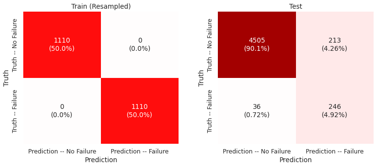

```python
# Plotting the confusion matrices of the productionized final model on training and test sets

# Reconstructing the training set
y_recon = clf_pipe.predict(X_train_pipe_resampled)
# Forecasting the test set
y_pred = clf_pipe.predict(X_test_pipe)

# Plotting the heatmaps of confusion matrices
plt.figure(figsize = (11, 5));
plt.subplot(121);
plot_cm(y_train_pipe_resampled, y_recon);
plt.title('Train (Resampled)');
plt.subplot(122);
plot_cm(y_test_pipe, y_pred);
plt.title('Test');
plt.tight_layout(w_pad = 3);
```

```python
# Reporting the performance of the productionized final model on training and test sets
pipe_perform = model_eval(clf_pipe, X_train_pipe_resampled, X_test_pipe,
                          y_train_pipe_resampled, y_test_pipe, valid = False)
pipe_perform
```

|  | Accuracy | Recall | Precision | F1 | Specificity |
| --- | --- | --- | --- | --- | --- |
| Train | 1.000 | 1.000 | 1.000 | 1.000 | 1.000 |
| Test | 0.950 | 0.872 | 0.536 | 0.664 | 0.955 |

```python
# Finding the region of uncertainty for the recall score of the final model

# Setting the strategy for splitting the data into 10 random folds
kfold = StratifiedKFold(n_splits = 10, shuffle = True, random_state = 1)

# Calculating the cross-validated scores
cv_results = cross_val_score(clf_pipe, X_train_pipe_resampled, y_train_pipe_resampled,
                             scoring = 'recall', cv = kfold, n_jobs = -1)
cv_mean = cv_results.mean()
cv_std  = cv_results.std()

# Reporting the model's average recall score and confidence interval
print('The average recall score of the productionized model is {} and,'.format(round(cv_mean, 3)),
      'with 95% certainty, its recall score resides between {} and {}.'.format(
          round(cv_mean-2*cv_std, 3), round(cv_mean+2*cv_std, 3)))
```

```
The average recall score of the productionized model is 0.909 and, with 95% certainty, its recall score resides between 0.852 and 0.966.
```

#### Observations:

The test precision score has increased slightly after deploying the model in production, perhaps since the model has been trained on a larger training set (the whole training data), but, overall, the productionized model reveals a very similar performance as before (e.g., identical test recall score).

# Business Insights and Conclusions

Here, we do not aim to present a lengthy summary of all findings. Instead, we briefly recapitulate major observations, and draw actionable recommendations from them.

*Observations and business recommendations:*

- Both training and testing datasets exhibited a drastic imbalance between the classes of the target variable (almost a 95/5 ratio for no failure to failure), signaling that resampling is crucial to construct a robust and reliable classification model.
- We demonstrated that the training and testing data come from the same populations, enabling the application of the ML-based models developed on the training data to the test data with no major loss of accuracy.
- Most variables were shown to come from nearly normal distributions.
- The final model, chosen based on its capability to maximize recall, was an undersampled and tuned XGBoost classifier with the recall score around 90% on the validation set, and almost the same (~ 87%) on the test set. It also had a decent precision score (> 50%) for a model optimized on recall.
- The undersampled Gradient Boosting classifier also showed a very similar performance to that of the final model, but since the mean and median of its cross-validated recall scores were slightly lower (and had a faintly smaller validation recall score), we selected the XGBoost Classifier as the final model.
- The oversampled models showed to typically have narrower confidence intervals (due to much their larger training set), but proved to be usually overfit, as their validation recall scores often didn't fall even in the confidence interval.
- Before tuning, the bagging methods revealed to be far more prone to overfitting than boosting methods or logistic regression.
- None of the variables really dominates the predictions of the final model. XGBoost classifier consists of hundreds of sequentially improved estimators and, due to the random mechanisms devised in it, each estimator may use a very diferent set of predictors, thus distributing the task of classification among a wide range of variables. Nonetheless, a few still stand out (e.g., V36, V18 and V39), and they may prove to be more significant indicators of failure than other predictors.

*Recommendations for future ML-based modeling:*

- A few of the features with high correlation with the target also appeared to be effective predictors of the target class as well. This shows a preliminary EDA can be helpful to determine what to expect from the final classification model, and how to reasonably and effectively tweak its hyperparameters. For instance, the number of predictors with high correlation with the target may give us some idea about a suitable range for the maximum depth.
- Using a KNN-based imputation scheme reveals to be really helpful when most vriables are numerical and continuous, and the number of missing records is small or moderate. This method can very well preserve the original distribution of variables, and doesn't cause concentration around the measures of central tendency and, consequently, doesn't cause significant reduction in standard deviation and variability. For this project, both simple imputer (using median as imputation strategy) and KNN imputer work fine and yield similar results, since only a very small fraction of entries were missing.